# Ecce Signum: Illustration

# Petrol

We examine Industrial Petroleum Consumption and OPEC Oil Imports, or *petrol* for short. (The two series are available from Department of Energy, Energy Information Administration.) Both series cover the period January 1973 through December 2016, and are seasonally adjusted.  
Industrial Petroleum Consumption is U.S. Product Supplied of Crude Oil and Petroleum Products, Monthly, in Thousand Barrels per Day. OPEC Oil Imports is Petroleum Imports from OPEC, in Thousand Barrels per Day. We perform a bivariate analysis by fitting the Local Level Model (LLM).

## Loading Packages

This code loads the data into a variable named **petrol**.

```r
## wipe
rm(list=ls())
library(devtools)
```

```
## Error in get(genname, envir = envir) : object 'testthat_print' not found
```

```r
library(Rcpp)

load_all(".")
```

```
## Loading sigex
```

```r
root.dir <- getwd()
```

## Enter Metadata

- We perform a bivariate analysis by fitting a structural model.
- First enter metadata, including starting date and frequency.

```r
start.date = c(1973,1)
period <- 12
```

- Next enter names of the series.
- The last argument of **sigex.load** generates a time series plot.

```r
dataALL.ts <- sigex.load(petrol[,c(1,2)],start.date,period,
                         c("Consumption","Imports"),TRUE)
```

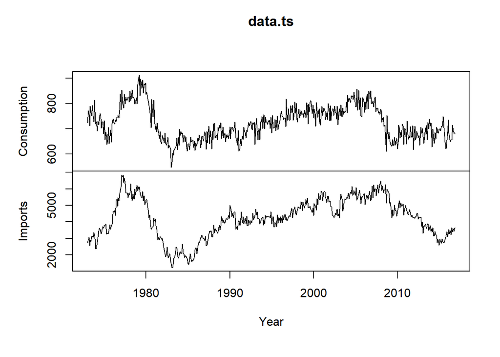

- On the basis of this plot, we decide (below) to utilize a log transformation for the data.

## Select Spans and Transforms

- We have the choice of either log or no log.
- The *aggregate* option will sum across the indicated series, in case we want to analyze an aggregate. Here we set it to FALSE.
- We can also select a subcomponent of series with *subseries*.
- The *range* argument of **sigex.prep** will select a subset of dates for the time series to be analyzed.

```r
transform <- "log"
aggregate <- FALSE
subseries <- c(1,2)
begin.date <- start(dataALL.ts)
end.date <- end(dataALL.ts)
range <- NULL
data.ts <- sigex.prep(dataALL.ts,transform,aggregate,subseries,range,TRUE)
```

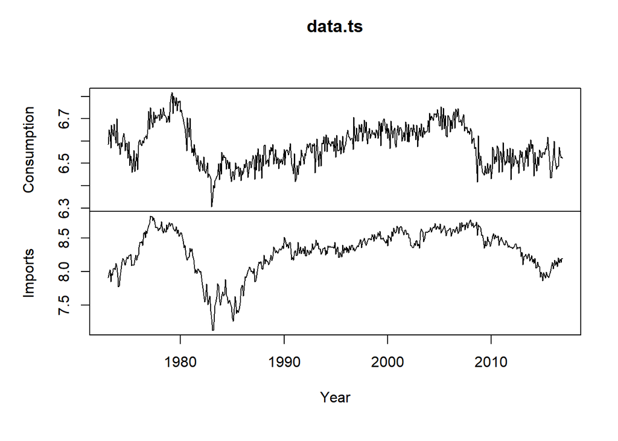

## Spectral Exploratory Analysis

- In order to get an idea about model specification, we can examine spectral estimates, using **sigex.specar**.
- We can look at raw data or differenced data (growth rates).

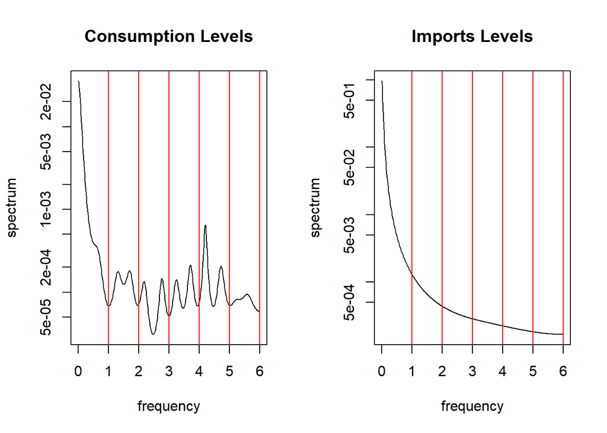

```r
# raw data
par(mfrow=c(1,2))
for(i in subseries) {   sigex.specar(data.ts,FALSE,i,period) }
```

```r
dev.off()
```

- From the raw data, it seems that trend differencing is appropriate.

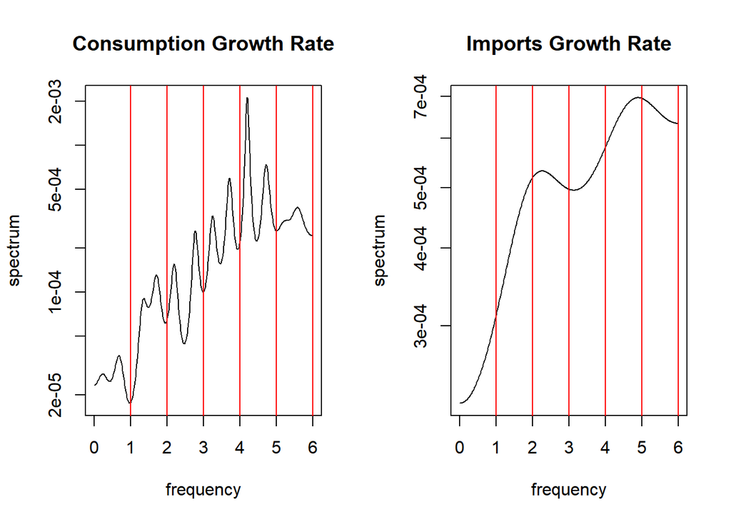

```r
# growth rates
par(mfrow=c(1,2))
for(i in subseries) {   sigex.specar(data.ts,TRUE,i,period) }
```

```r
dev.off()
```

- These plots indicate that a single differencing of the data may be appropriate.

## Model Declaration

- Exploratory analysis indicates we should consider a model with trend and irregular effects.
- We begin by defining dimension $N$ and sample size $T$.

```r
N <- dim(data.ts)[2]
T <- dim(data.ts)[1]
```

### Default Model: Related Trends

- The basic LLM is referred to as a *related trends model*. This case has full rank covariance matrices for trend (and irregular).
- The list object *mdl* stores all our specifications about the model, but none of the parameter estimates.

```r
mdl <- NULL
mdl <- sigex.add(mdl,seq(1,N),"arma",c(0,0),NULL,"trend",c(1,-1))
mdl <- sigex.add(mdl,seq(1,N),"arma",c(0,0),NULL,"irregular",1)
```

- Each of the two latent processes is labeled, and has a distinct differencing polynomial, whose application produces a full-rank white noise.
- The multiple calls to **sigex.add** adds each latent process consecutively into the existing model.
- The second argument indicates the rank configuration; setting *vrank* equal to seq(1,N) ensures a full rank covariance matrix.
- The third argument gives the model type as *arma*; the order $p=0$, $q=0$ indicates a white noise.
- The sixth argument associates a label.

```r
mdl <- sigex.meaninit(mdl,data.ts,0)
```

- There are no regressors specified, but we still need to call **sigex.meaninit** so that the time trend polynomial is set up correctly.
- The last argument gives the order of this time trend polynomial. The value $0$ indicates there is a constant mean effect assumed.

### Alternate Model: Common Trends

- The *common trends model* is a type of LLM where it is enforced that $\Sigma^{(1)}$ has rank one.
- The only difference from the default model is that *vrank* equals 1, in the first line.

```r
mdl2 <- NULL
mdl2 <- sigex.add(mdl2,1,"arma",c(0,0),NULL,"trend",c(1,-1))
mdl2 <- sigex.add(mdl2,seq(1,N),"arma",c(0,0),NULL,"irregular",1)
mdl2 <- sigex.meaninit(mdl2,data.ts,0)
```

## Model Estimation of Related Trends Model

### Initialization

- First we need to initialize. The variable *psi.mle* correspond to the pre-parameters, and get mapped to *par.mle*, the parameters, via **sigex.psi2par**.

```r
constraint <- NULL
par.mle <- sigex.default(mdl,data.ts,constraint)
psi.mle <- sigex.par2psi(par.mle,mdl)
```

### MLE Fitting

- Maximum Likelihood Estimation is done using BFGS. We use the divergence, which is $-2$ times the log Gaussian likelihood, with constants removed.
- With the debug option set to TRUE, the values of the divergence are printed to the console.

```r
fit.mle <- sigex.mlefit(data.ts,par.mle,constraint,mdl,"bfgs",debug=FALSE)
psi.mle <- sigex.eta2psi(fit.mle[[1]]$par,constraint)
hess <- fit.mle[[1]]$hessian
par.mle <- fit.mle[[2]]
```

- This yields a divergence of -5043.9381432.

### Residual Analysis

- We obtain, format, and store the residuals.
- Then we compute the autocorrelations, and plot.

```r
resid.mle <- sigex.resid(psi.mle,mdl,data.ts)[[1]]
resid.mle <- sigex.load(t(resid.mle),start(data.ts),frequency(data.ts),
                        colnames(data.ts),TRUE)
```

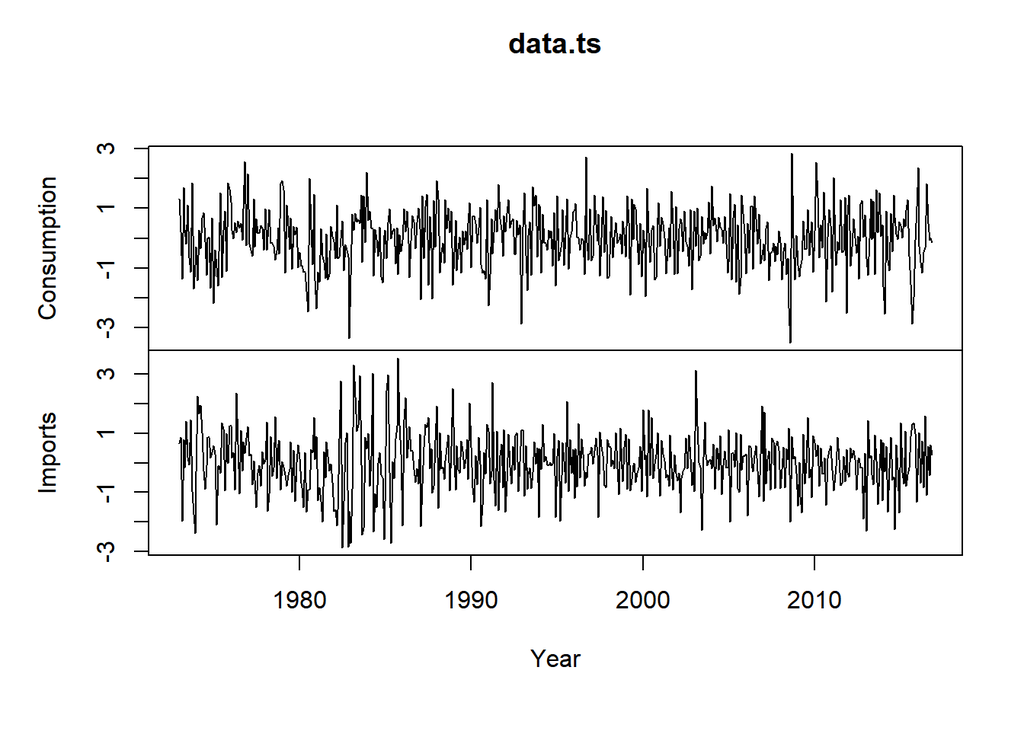

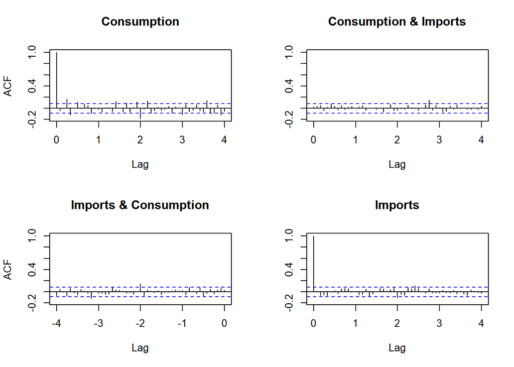

```r
resid.acf <- acf(resid.mle,lag.max=4*period,plot=TRUE)$acf
```

- We can also examine the condition numbers, to see if there is rank reduction possible.

```r
log(sigex.conditions(data.ts,psi.mle,mdl))
```

```
##      [,1]        [,2]
## eta2    0 -0.08872153
## eta2    0 -0.04273439
```

### Model Checking

- We can examine the Portmanteau statistic for residual serial correlation. We use $48$ lags.
- We can also inspect normality via the Shapiro-Wilks normality test.

```r
sigex.portmanteau(resid.mle,4*period,length(psi.mle))
```

```
## [1] 3.241444e+02 8.243882e-10
```

```r
sigex.gausscheck(resid.mle)
```

```
## [1] 0.162404329 0.001750402
```

- We can also examine the Hessian matrix, and compute the t statistics for pre-parameters.

```r
print(eigen(hess)$values)
```

```
## [1] 5.715669e+06 3.125780e+05 3.973110e+02 3.500380e+02 2.722189e+02
## [6] 6.162137e+01 2.193493e+01 5.617884e+00
```

- If the Hessian is not positive definite (this can happen if nonlinear optimization terminates wrongfully at a saddlepoint), then the standard error is set to zero.
- In this case there is no problem.

```r
tstats <- sigex.tstats(mdl,psi.mle,hess,constraint)
print(tstats)
```

```
## [1]   2.0440773 -47.5396071 -29.3293629   2.1992793 -89.0721340 -25.0596186
## [7]  -0.2942325   0.1744484
```

- These results could be used to insert zeroes in the pre-parameters, although they need not correspond to zeroes in the parameters.

### Bundle

- Having completed our model analysis, we store our results in a single list object.

```r
analysis.mle <- sigex.bundle(data.ts,transform,mdl,psi.mle)
```

## Model Estimation of Common Trends Model

### Initialization

- First we need to initialize. The variable *psi.mle2* correspond to the pre-parameters, and get mapped to *par.mle2*, the parameters, via **sigex.psi2par**.
- We construct initial estimates from the fitted related trends model: the pre-parameters associated with the trend innovation covariance matrix are altered to correspond to a full-correlation matrix (but with the same variances).

```r
cov.mat <- par.mle[[1]][[1]] %*% diag(exp(par.mle[[2]][[1]])) %*%
  t(par.mle[[1]][[1]])
l.trend <- sqrt(cov.mat[2,2]/cov.mat[1,1])
d.trend <- cov.mat[1,1]
```

- The lower entry of the matrix $L$ in the Generalized Cholesky Decomposition (GCD) of the trend covariance matrix is set equal to $\sigma_2 / \sigma_1$.
- The first entry of the matrix $D$ in the GCD is set equal to $\sigma_1^2$.
- Now we initialize.

```r
constraint <- NULL
psi.mle2 <- c(l.trend,log(d.trend),psi.mle[4:8])
par.mle2 <- sigex.psi2par(psi.mle2,mdl2,data.ts)
```

### MLE Fitting

- Maximum Likelihood Estimation is done using BFGS.
- With the debug option set to TRUE, the values of the divergence are printed to the console.

```r
fit.mle2 <- sigex.mlefit(data.ts,par.mle2,constraint,mdl2,"bfgs",debug=FALSE)
psi.mle2 <- sigex.eta2psi(fit.mle2[[1]]$par,constraint)
hess2 <- fit.mle2[[1]]$hessian
par.mle2 <- fit.mle2[[2]]
```

- This yields a divergence of -4600.6304593.

### Residual Analysis

- We obtain, format, and store the residuals.
- Then we compute the autocorrelations, and plot.

```r
resid.mle2 <- sigex.resid(psi.mle2,mdl2,data.ts)[[1]]
resid.mle2 <- sigex.load(t(resid.mle2),start(data.ts),frequency(data.ts),
                         colnames(data.ts),TRUE)
```

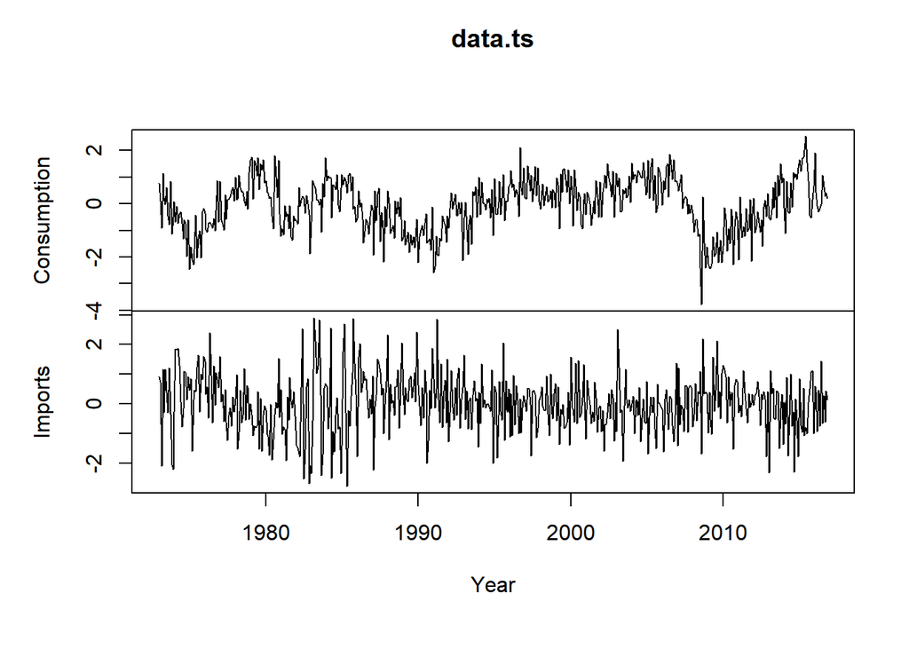

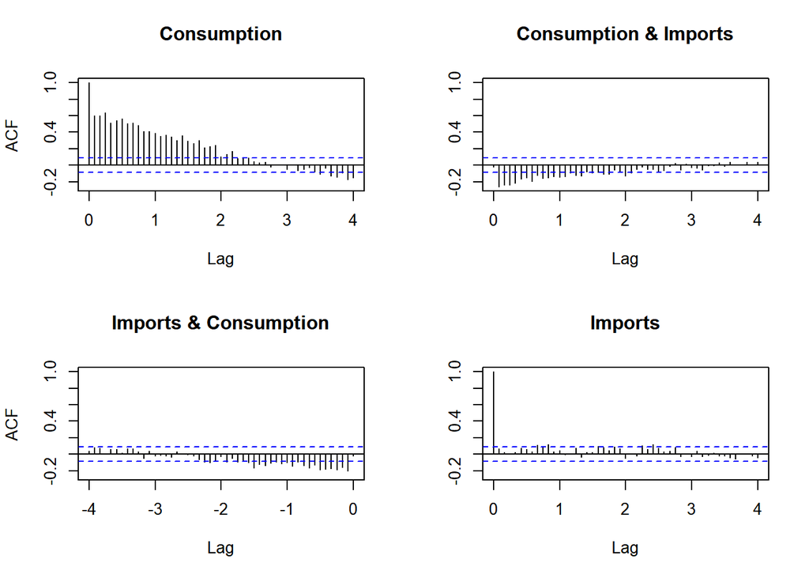

```r
resid.acf2 <- acf(resid.mle2,lag.max=4*period,plot=TRUE)$acf
```

- We already have done the rank reduction, and can verify this by examining the condition numbers.

```r
log(sigex.conditions(data.ts,psi.mle2,mdl2))
```

```
##      [,1]       [,2]
## eta2    0       -Inf
## eta2    0 -0.1413142
```

### Model Checking

- We can examine the Portmanteau statistic for residual serial correlation. We use $48$ lags.
- We can also inspect normality via the Shapiro-Wilks normality test.

```r
sigex.portmanteau(resid.mle2,4*period,length(psi.mle2))
```

```
## [1] 2912.267    0.000
```

```r
sigex.gausscheck(resid.mle2)
```

```
## [1] 0.0006640736 0.0123199699
```

- We can also examine the Hessian matrix, and compute the t statistics for pre-parameters.

```r
print(eigen(hess2)$values)
```

```
## [1] 6.572794e+09 2.695333e+05 6.595557e+02 3.415959e+02 2.555340e+02
## [6] 5.829408e+01 3.052983e+01
```

- If the Hessian is not positive definite (this can happen if nonlinear optimization terminates wrongfully at a saddlepoint), then the standard error is set to zero.
- In this case there is no problem.

```r
tstats2 <- sigex.tstats(mdl2,psi.mle2,hess2,constraint)
print(tstats2)
```

```
## [1]  26.05529558 -58.18765203  -2.92779200 -80.86800064 -28.16342844
## [6]  -0.08949509   0.18654964
```

- These results could be used to insert zeroes in the pre-parameters, although they need not correspond to zeroes in the parameters.

### Bundle

- Having completed our model analysis, we store our results in a single list object.

```r
analysis.mle2 <- sigex.bundle(data.ts,transform,mdl2,psi.mle2)
```

### Model Comparison

- The common trends model is quite a bit worse, having a much higher divergence.
- A likelihood comparison statistic for nested models is computed using **sigex.glr**, and the p-value is obtained in the second line.

```r
test.glr <- sigex.glr(data.ts,psi.mle2,psi.mle,mdl2,mdl)
print(c(test.glr[1],1-pchisq(test.glr[1],df=test.glr[2])))
```

```
## [1] 443.3077   0.0000
```

## Signal Extraction

- Finally, we consider trend extraction using either model.
- Here we will use the matrix formula approach to signal extraction.

### Trend Extraction for Related Trends Model

- First we reload from the bundle.

```r
data.ts <- analysis.mle[[1]]
mdl <- analysis.mle[[3]]
psi <- analysis.mle[[4]]
param <- sigex.psi2par(psi,mdl,data.ts)
```

- The first step is to get the matrix filters.
- There are two latent processes (trend and irregular), and the filters for these are obtained using **sigex.signal**.
- This function’s last argument is *sigcomps*, a vector of indices denoting the composition of the desired signal.
- *signal.trend* is the trend variable, and is composed of just the first latent process, so the value of *sigcomps* is $1$.

```r
signal.trend <- sigex.signal(data.ts,param,mdl,1)
signal.irr <- sigex.signal(data.ts,param,mdl,2)
```

- The second step is to compute the extractions.
- *extract.trend* is defined as a list object, with first item corresponding to a $T \times N$ matrix of trend extractions. The second and third items of the list give upper and lower bounds of confidence intervals, based on $\pm 2$ square root signal extraction MSE.

```r
extract.trend <- sigex.extract(data.ts,signal.trend,mdl,param)
extract.irr <- sigex.extract(data.ts,signal.irr,mdl,param)
```

```r
reg.trend <- NULL
for(i in 1:N) {
reg.trend <- cbind(reg.trend,sigex.fixed(data.ts,mdl,i,param,"Trend")) }
```

- The results can be displayed using calls to **sigex.graph**.
- This code sets up a red color for the trend in *trendcol*, and a shading percentage *fade*.
- For each component time series, the raw data is plotted (in logarithms) and overlaid with the trend.
- The first argument of **sigex.graph** takes the extracted list object *extract.trend*, and any fixed effects that should be added must be included in the second argument.
- The sixth argument allows for a vertical displacement in case one does not wish to overlay the extraction on top of the data; setting to zero indicates no displacement.
- The last argument determines the darkness of shading corresponding to the signal extraction uncertainty.

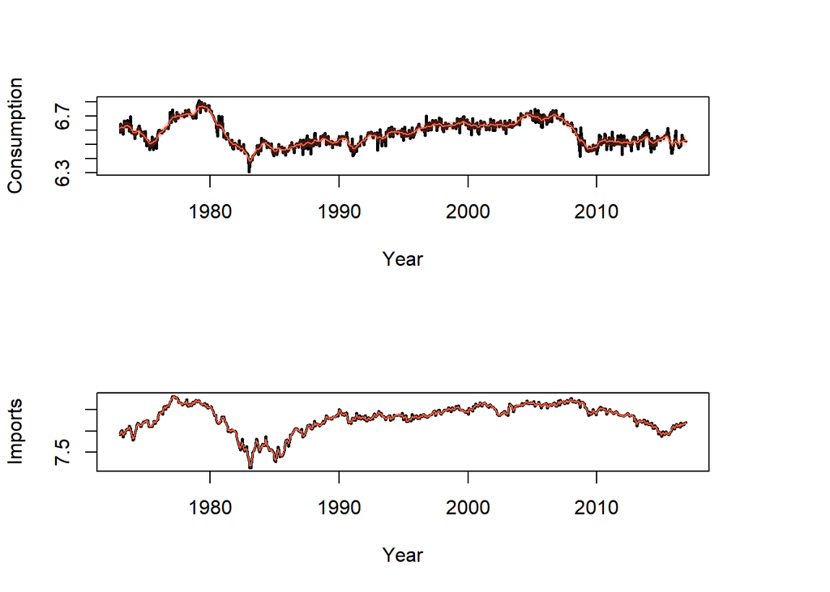

```r
trendcol <- "tomato"
fade <- 40
par(mfrow=c(2,1),mar=c(5,4,4,5)+.1)
for(i in 1:N)
{
    plot(data.ts[,i],xlab="Year",ylab=colnames(data.ts)[i],ylim=c(min(data.ts[,i]),max(data.ts[,i])),
        lwd=2,yaxt="n",xaxt="n")
    sigex.graph(extract.trend,reg.trend,begin.date,period,i,0,trendcol,fade)
    axis(1,cex.axis=1)
    axis(2,cex.axis=1)
}
```

```r
dev.off()
```

- One can examine the frequency response functions for Wiener-Kolmogorov filters through **sigex.getfrf**, which can also plot the real portions.

```r
grid <- 1000
frf.trend <- sigex.getfrf(data.ts,param,mdl,1,TRUE,grid)
```

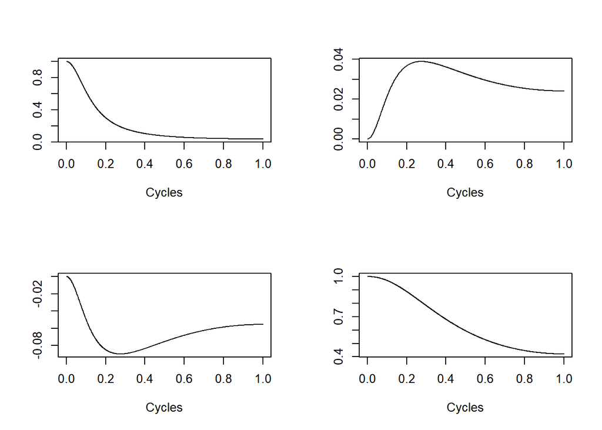

- The *grid* argument corresponds to a mesh of frequencies in $[0, \pi]$, and the fourth argument of **sigex.getfrf** indicates the combination of components desired.
- One can also examine the Wiener-Kolmogorov filter coefficients.

```r
len <- 50
target <- array(diag(N),c(N,N,1))
wk.trend <- sigex.wk(data.ts,param,mdl,1,target,TRUE,grid,len)
```

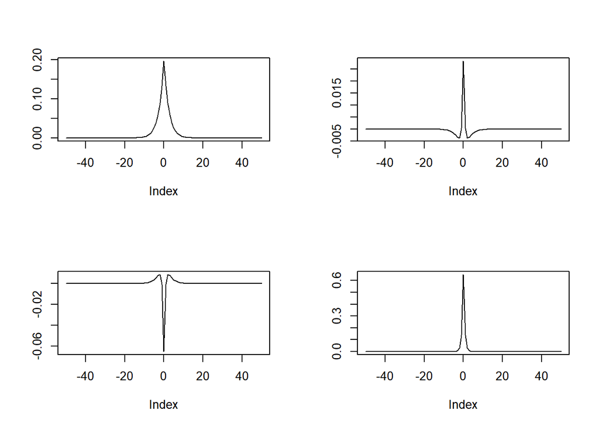

- The *target* argument indicates that no linear combination of the trend is being considered here.
- *len* is set to $50$, so that the indices of the filter run from $-50$ up to $50$.

### Trend Extraction for Common Trends Model

- First we reload from the bundle for the alternate model.

```r
data.ts <- analysis.mle2[[1]]
mdl <- analysis.mle2[[3]]
psi <- analysis.mle2[[4]]
param <- sigex.psi2par(psi,mdl,data.ts)
```

- The first step is to get the matrix filters.
- There are two latent processes (trend and irregular), and the filters for these are obtained using **sigex.signal**.
- This function’s last argument is *sigcomps*, a vector of indices denoting the composition of the desired signal.
- *signal.trend* is the trend variable, and is composed of just the first latent process, so the value of *sigcomps* is $1$.

```r
signal.trend <- sigex.signal(data.ts,param,mdl,1)
signal.irr <- sigex.signal(data.ts,param,mdl,2)
```

- The second step is to compute the extractions.
- *extract.trend* is defined as a list object, with first item corresponding to a $T \times N$ matrix of trend extractions. The second and third items of the list give upper and lower bounds of confidence intervals, based on $\pm 2$ square root signal extraction MSE.

```r
extract.trend <- sigex.extract(data.ts,signal.trend,mdl,param)
extract.irr <- sigex.extract(data.ts,signal.irr,mdl,param)
```

```r
reg.trend <- NULL
for(i in 1:N) {
reg.trend <- cbind(reg.trend,sigex.fixed(data.ts,mdl,i,param,"Trend")) }
```

- The results can be displayed using calls to **sigex.graph**.
- This code sets up a red color for the trend in *trendcol*, and a shading percentage *fade*.
- For each component time series, the raw data is plotted (in logarithms) and overlaid with the trend.
- The first argument of **sigex.graph** takes the extracted list object *extract.trend*, and any fixed effects that should be added must be included in the second argument.
- The sixth argument allows for a vertical displacement in case one does not wish to overlay the extraction on top of the data; setting to zero indicates no displacement.
- The last argument determines the darkness of shading corresponding to the signal extraction uncertainty.

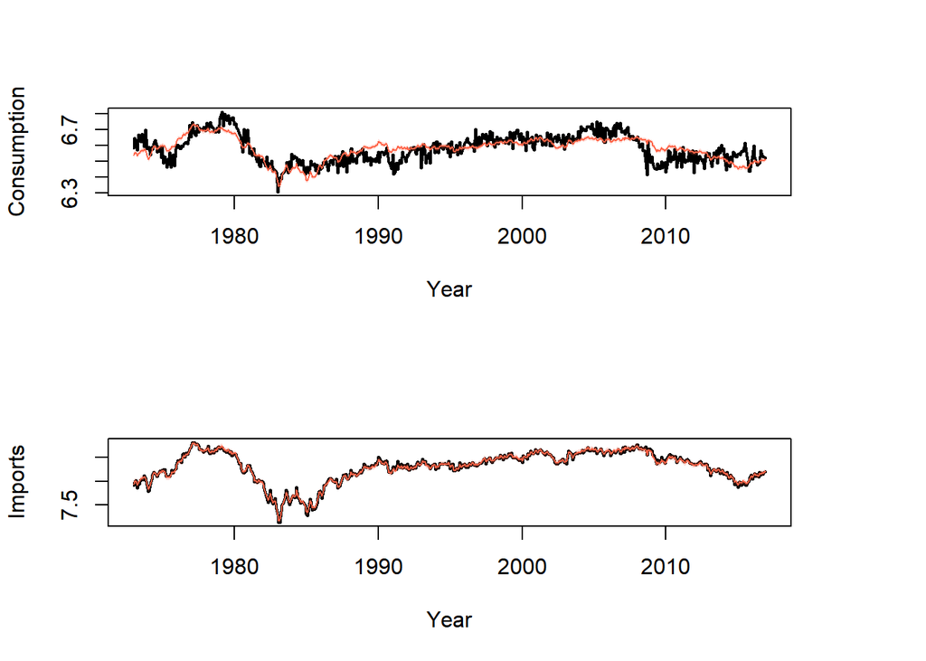

```r
trendcol <- "tomato"
fade <- 40
par(mfrow=c(2,1),mar=c(5,4,4,5)+.1)
for(i in 1:N)
{
    plot(data.ts[,i],xlab="Year",ylab=colnames(data.ts)[i],ylim=c(min(data.ts[,i]),max(data.ts[,i])),
        lwd=2,yaxt="n",xaxt="n")
    sigex.graph(extract.trend,reg.trend,begin.date,period,i,0,trendcol,fade)
    axis(1,cex.axis=1)
    axis(2,cex.axis=1)
}
```

```r
dev.off()
```

- One can examine the frequency response functions for Wiener-Kolmogorov filters through **sigex.getfrf**, which can also plot the real portions.

```r
grid <- 1000
frf.trend <- sigex.getfrf(data.ts,param,mdl,1,TRUE,grid)
```

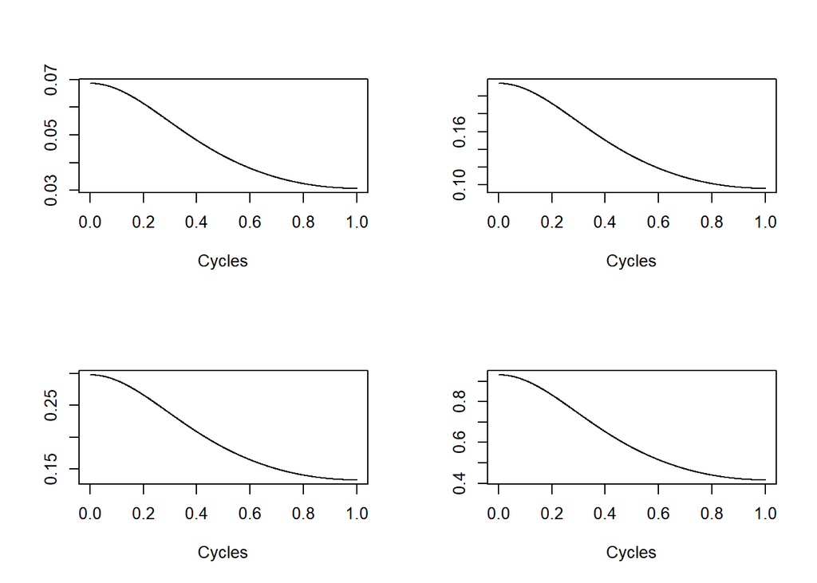

- The *grid* argument corresponds to a mesh of frequencies in $[0, \pi]$, and the fourth argument of **sigex.getfrf** indicates the combination of components desired.
- One can also examine the Wiener-Kolmogorov filter coefficients.

```r
len <- 50
target <- array(diag(N),c(N,N,1))
wk.trend <- sigex.wk(data.ts,param,mdl,1,target,TRUE,grid,len)
```

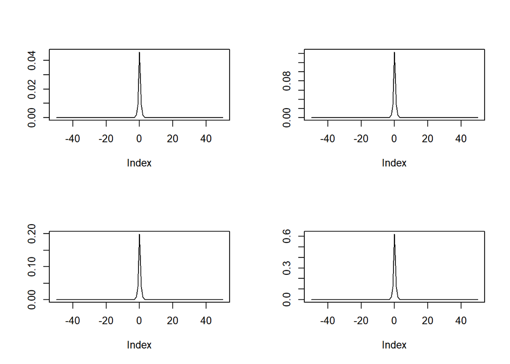

- The *target* argument indicates that no linear combination of the trend is being considered here.
- *len* is set to $50$, so that the indices of the filter run from $-50$ up to $50$.